# Lab 2

Amy, Ksenia, and Rebecca

January 30, 2022

### 1.Start with the google trends data.

#### Visualize the change in trends for each hurricane over time in one plot with three scales. Map color to a discrete scale.

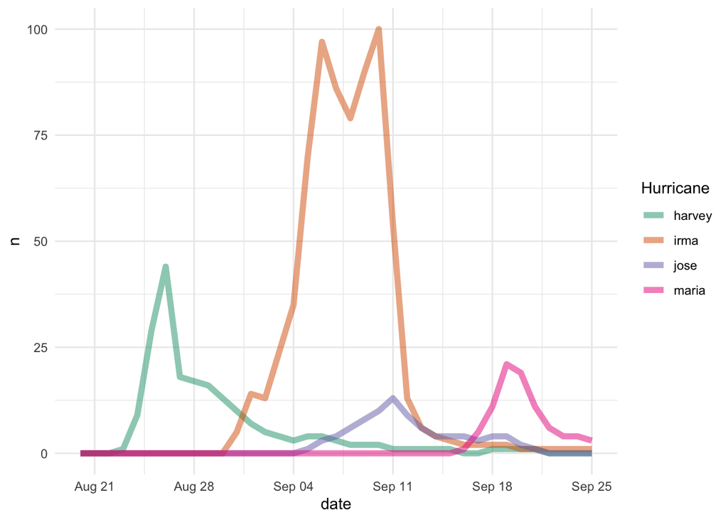

```r
trends <- google_trends

trends$date <- ymd(trends$date)

trends_pivot <- trends %>%
    pivot_longer(
        cols = starts_with("hurricane"),
        names_to = c("Hurricane", "name"),
        values_to = "n",
        names_sep = "_",
        values_drop_na = TRUE,
        names_repair = "check_unique",
        names_prefix = "hurricane_"
    )

ggplot(trends_pivot,aes(date, n)) +
    geom_line(aes(color = Hurricane), alpha = .5, size = 2) +
    scale_color_brewer(palette = "Dark2") +
    theme_minimal()
```

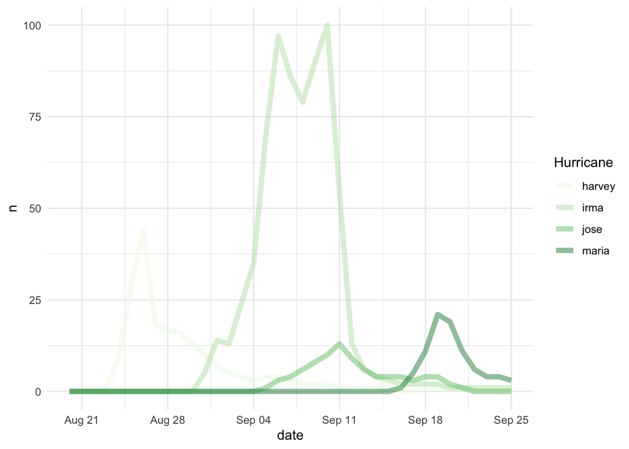

```r
ggplot(trends_pivot,aes(date, n)) +
    geom_line(aes(color = Hurricane), alpha = .5, size = 2) +
    scale_color_brewer(palette = "Dark1") +
    theme_minimal()
```

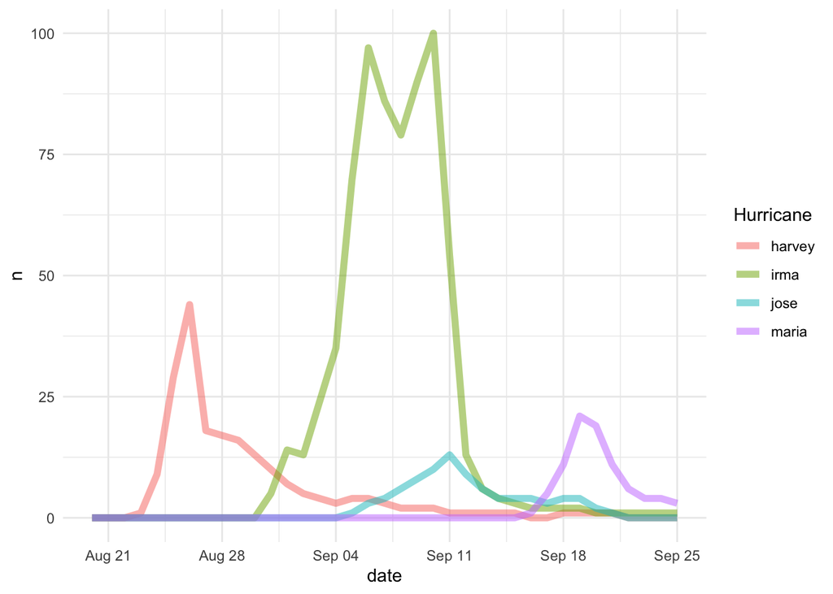

```r
ggplot(trends_pivot,aes(date, n)) +
    geom_line(aes(color = Hurricane), alpha = .5, size = 2) +
    scale_color_discrete() +
    theme_minimal()
```

#### Visualize the trends again, this time with solid shapes (if your first plot was already solid shapes, use lines). Hint, geom_area can be difficult to work with if you have a grouping factor. Try geom_ribbon instead.

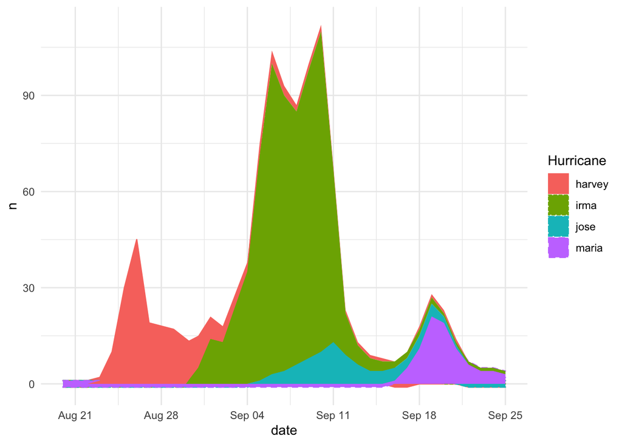

```r
ggplot(trends_pivot, aes(x = date, y = n)) +
    geom_ribbon(aes(x = date, y = n, ymin = n - 1, ymax = n + 1, fill = Hurricane, color = Hurricane, linetype = Hurricane)) +
    geom_area(aes(fill = Hurricane)) +
    theme_minimal()
```

#### Visualize the same relation, but change the scales so color is mapped to a continuous scale (the other scales should be discrete).

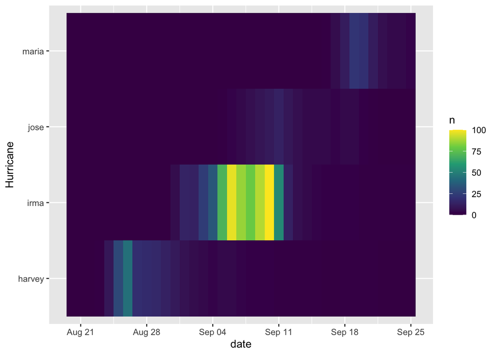

```r
ggplot(trends_pivot, aes(x = date, y = Hurricane, fill = n)) +
    geom_tile() +
    scale_fill_continuous(type = "viridis")
```

#### Create a data frame (using tibble() or data.frame()) that includes the dates that each hurricane made landfall. Annotate one of your first two plots to include these reference points with vertical lines (Hint: use geom_vline(), specifying the data source for this layer as this new dataset). You do not have to include text annotations - just the vertical lines, but if you would like to try, look into geom_text() or geom_label().

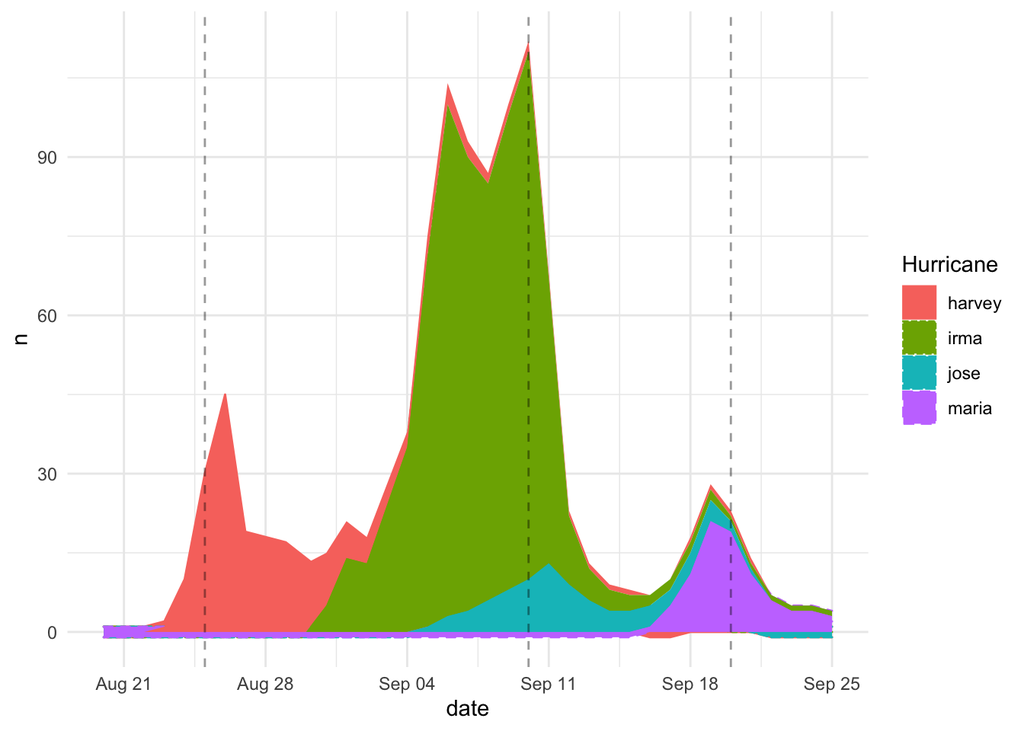

```r
# Didn't include Jose b/c no reference line is needed since it didn't make landfall

landfall <- tibble(Hurricane = c("Harvey",
                                  "Irma",
                                  "Maria"),
                    Date = c("August 25, 2017",
                             "September 10, 2017",
                             "September 20, 2017"),
                    numdate = c("2017-08-25",
                                "2017-09-10",
                                "2017-09-20"))

# Overlaid vertical reference lines on top of the filled line graph

ggplot(trends_pivot,
       aes(x = date,
           y = n)) +
    geom_ribbon(aes(x = date,
                    y = n,
                    ymin = n - 1,
                    ymax = n + 1,
                    fill = Hurricane,
                    color = Hurricane,
                    linetype = Hurricane)) +
    geom_area(aes(fill = Hurricane)) +
    theme_minimal() +
  geom_vline(aes(xintercept = ymd(numdate)),
             data = landfall,
             lty = 2,
             alpha = 0.4)
```

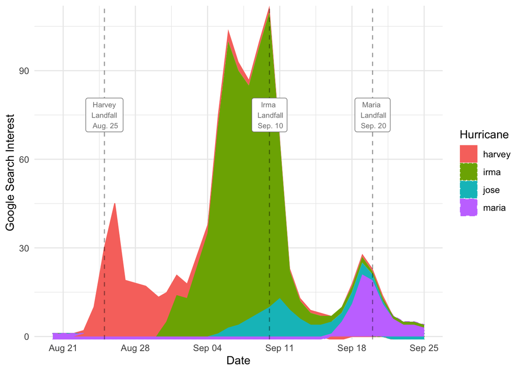

```r
# Added labels to vertical reference lines
ggplot(trends_pivot,
       aes(x = date,
           y = n)) +
    geom_ribbon(aes(x = date,
                    y = n,
                    ymin = n - 1,
                    ymax = n + 1,
                    fill = Hurricane,
                    color = Hurricane,
                    linetype = Hurricane)) +
    geom_area(aes(fill = Hurricane)) +
    theme_minimal() +
  scale_y_continuous(expand = c(0,0)) +
  labs(x = "Date",
       y = "Google Search Interest") +
  geom_vline(aes(xintercept = ymd(numdate)),
             data = landfall,
             lty = 2,
             alpha = 0.4) +
  geom_label(data = landfall,
             aes(x = ymd(numdate),
                 y = 75,
                 label = c("Harvey
 Landfall
 Aug. 25",
                           "Irma
 Landfall
 Sep. 10",
                           "Maria
 Landfall
 Sep. 20")),
           color = "gray50",
           size = 2.5)
```

### part 2. Replicate the “National cable news networks” plot from the story using the tv_states data. Don’t worry about all the labels. Try to match the colors but don’t worry about getting them exact.

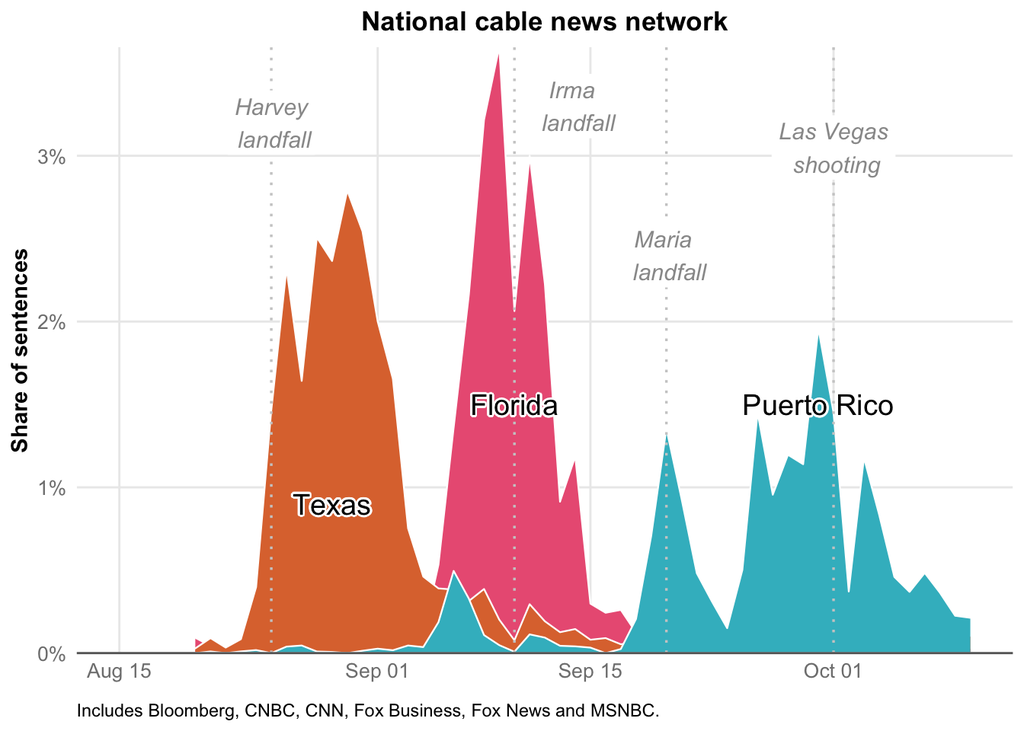

```r
tv_states$date <- ymd(tv_states$date)

states_pivot <- tv_states %>%
    pivot_longer(!date,
        names_to = "state",
        values_to = "share")

states_pivot <- states_pivot %>%
  mutate(
    state = case_when(
      state == "florida" ~ "Florida",
      state == "texas" ~ "Texas",
      state == "puerto_rico" ~ "Puerto Rico"
    ))

states_pivot$state <- factor(states_pivot$state, levels = c("Florida", "Texas", "Puerto Rico"))

labels_part2 <- tibble(event = c("Harvey",
                                  "Irma",
                                  "Maria",
                                 "Las Vegas"),
                    Date = c("August 25, 2017",
                             "September 10, 2017",
                             "September 20, 2017",
                             "October 1, 2017"),
                    numdate = c("2017-08-25",
                                "2017-09-10",
                                "2017-09-20",
                                "2017-10-01"))

labels3 <- tibble(x = c(ymd("2017-08-29"),
                        ymd("2017-09-10"),
                        ymd("2017-09-30")),
                 y = c(0.9, 1.5, 1.5),
                 label = c("Texas",
                           "Florida",
                           "Puerto Rico"))

ggplot(states_pivot,
       aes(x = date,
           y = share)) +
    geom_ribbon(aes(x = date,
                    y = share,
                    xmin = ymd("2017-08-15"),
                    ymin = -Inf,
                    ymax = share,
                    fill = state,
                    color = state,
                    linetype = state),
                color = "white",
                size = 0.4,
                linetype = "solid") +
    theme_minimal() +
  scale_fill_manual(values = c("#eb6083",  "#de743c", "#3bbac8")) +
  scale_y_continuous(expand = c(0,0), labels = function(share) paste0(share,"%")) +
  labs(x = element_blank(),
       y = "Share of sentences",
       title = "National cable news network",
       caption = "Includes Bloomberg, CNBC, CNN, Fox Business, Fox News and MSNBC.") +
  geom_vline(aes(xintercept = ymd(numdate)),
             data = labels_part2,
             linetype = 'dotted',
             size = 0.6,
             alpha = 1,
             color = "grey80") +
  geom_label(data = labels_part2,
             aes(x = c(ymd(numdate[1]),
                       ymd("2017-09-14"),
                       ymd(numdate[3]),
                       ymd(numdate[4])),
                 y = c(3.2, 3.3, 2.4, 3.05),
                 label = c("Harvey
 landfall",
                           "Irma
 landfall",
                           "Maria
 landfall",
                            "Las Vegas
 shooting"),
 fill = NULL),
                 color = "gray60",
                 size = 4,
                 fontface = "italic",
                 label.size = NA) +
  geom_shadowtext(data = labels3,
                  aes(x = x,
                      y = y,
                      label = label),
                  color = "black",
                  bg.color ="white",
                  size = 5) +
  theme(panel.grid.minor.x = element_blank(),
        panel.grid.minor.y = element_blank(),
        axis.line.x = element_line(size = 0.5, color = "grey40"),
        plot.title = element_text(hjust = 0.5, face = "bold"),
        axis.title.y = element_text(face = "bold"),
        axis.text = element_text(color = "gray50", size = 10),
        plot.caption = element_text(hjust = 0),
        legend.position = "none")
```

### 3. Use the comic_characters dataset to visualize the proportion of different genders using at least three different methods. With your final visualization, make any additional modifications you think would help reduce the cognitive load necessary to comprehend the figure.

```r
# Load the data
comic <- comic_characters

# Take a look at the ns
comic %>%
  group_by(sex) %>%
  summarize(n = n())
```

```
## # A tibble: 7 x 2
##   sex                        n
##   <chr>                  <int>
## 1 Agender Characters        45
## 2 Female Characters       5804
## 3 Genderfluid Characters     2
## 4 Genderless Characters     20
## 5 Male Characters        16421
## 6 Transgender Characters     1
## 7 <NA>                     979
```

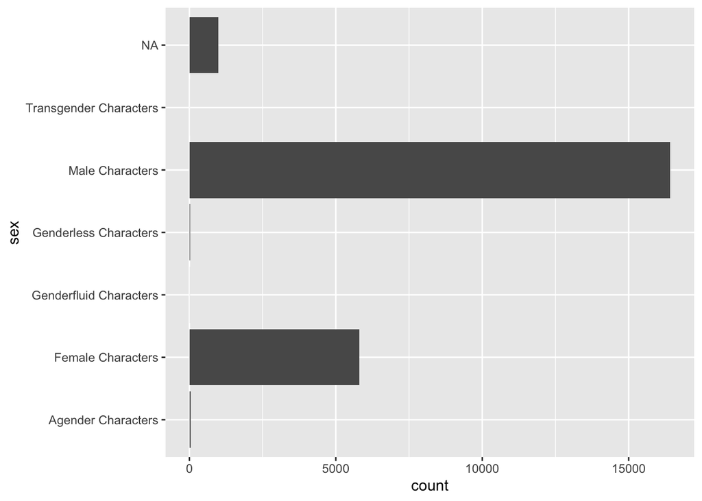

```r
# Prelim plot
comic %>%
  ggplot(aes(sex)) +
  geom_bar() +
  coord_flip()
```

```r
# New tibble w/ proportions by gender
genderprop <- comic %>%
  group_by(sex) %>%
  summarize(n = n(),
            proportion = (n()/nrow(comic)))

# Set gender as a factor
genderprop <- genderprop %>%
  mutate(sex = as_factor(sex))

# Change "NA" Gender to "Missing"
genderprop$sex <- fct_explicit_na(genderprop$sex, na_level = "Missing")

# Remove "Characters" from levels of gender variable
genderprop$sex <- recode_factor(genderprop$sex,
                                `Male Characters` = "Male",
                                `Female Characters` = "Female",
                                `Agender Characters` = "Agender",
                                `Genderless Characters` = "Genderless",
                                `Genderfluid Characters` = "Genderfluid",
                                `Transgender Characters` = "Transgender")
```

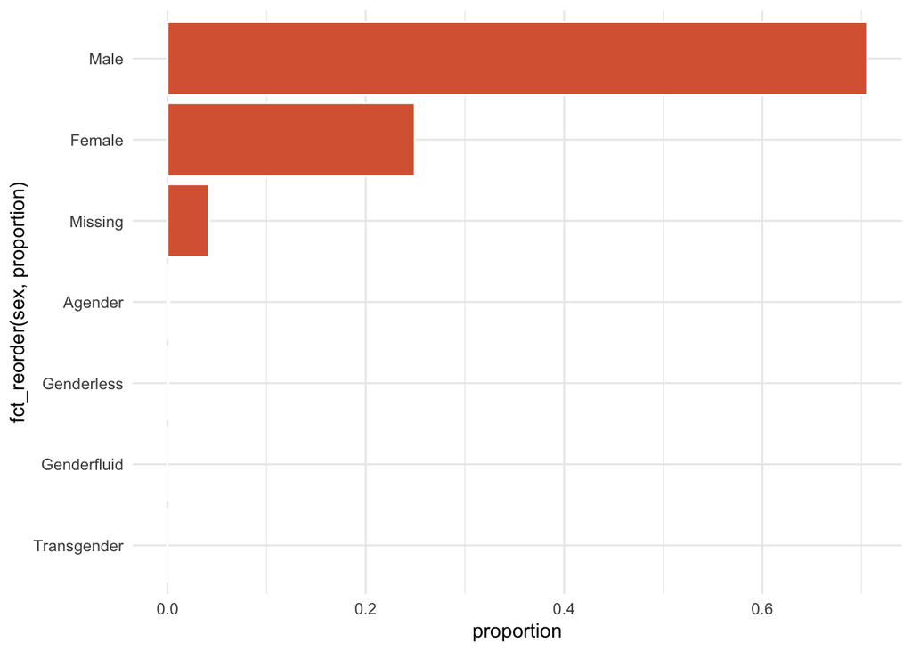

```r
genderprop %>%
  ggplot(aes(fct_reorder(sex, proportion), proportion)) +
  geom_col(fill = "#DA6541",
           color = "#FFFFFF") +
  coord_flip() +
  theme_minimal()
```

#### Plot 2 - Waffle chart

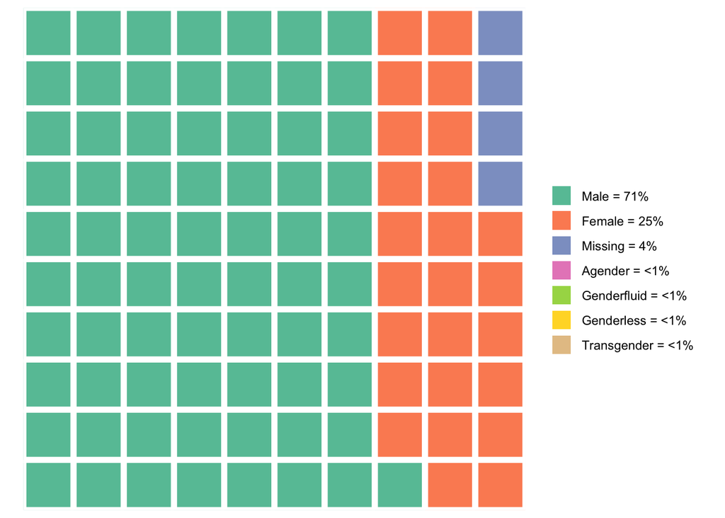

```r
# Waffle Chart v1. Challenging due to percentages and rounding. If 100 squares are used, none can be assigned to Agender, Genderless, Genderfluid, or Transgender. In this first version, I still included these categories in the key. However, that could be confusing to the reader since colors are assigned to the categories but they aren't in the graph. The default colors (set2) are used.
genderpropwaffle1 <- c(`Male = 71%` = 71,
                      `Female = 25%` = 25,
                      `Missing = 4%` = 4,
                      `Agender = <1%` = 0,
                      `Genderfluid = <1%` = 0,
                      `Genderless = <1%` = 0,
                      `Transgender = <1%` = 0)

waffle(genderpropwaffle1)
```

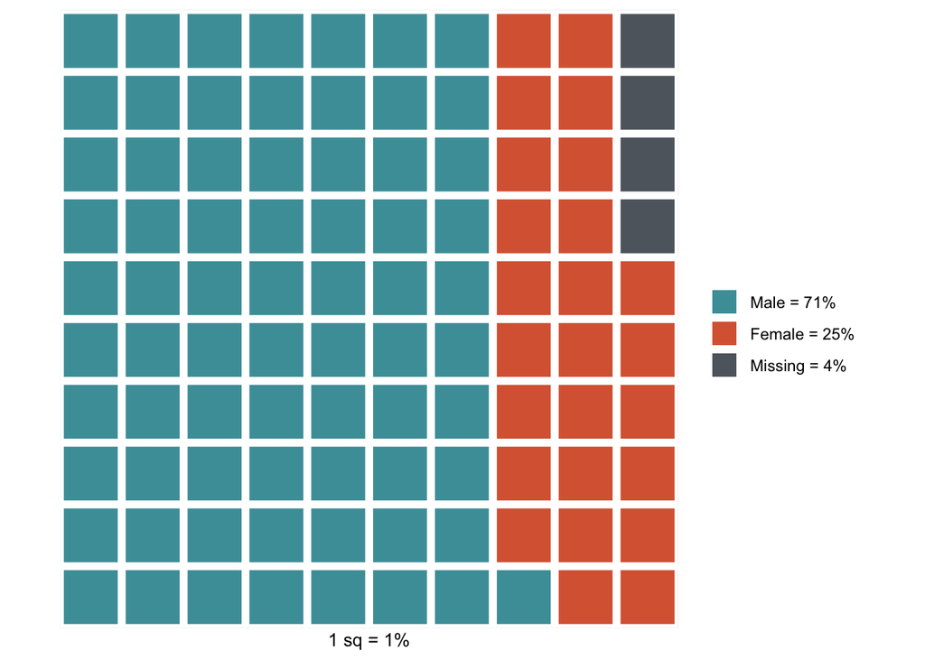

```r
# Waffle v2. Top three categories. I don't like this one because not all gender categories are represented.

genderpropwaffle2 <- c(`Male = 71%` = 71,
                       `Female = 25%` = 25,
                       `Missing = 4%` = 4)

waffle(genderpropwaffle2,
       colors = c("#4B9EA8",
                  "#DA6541",
                  "#5F666E"),
       xlab = "1 sq = 1%")
```

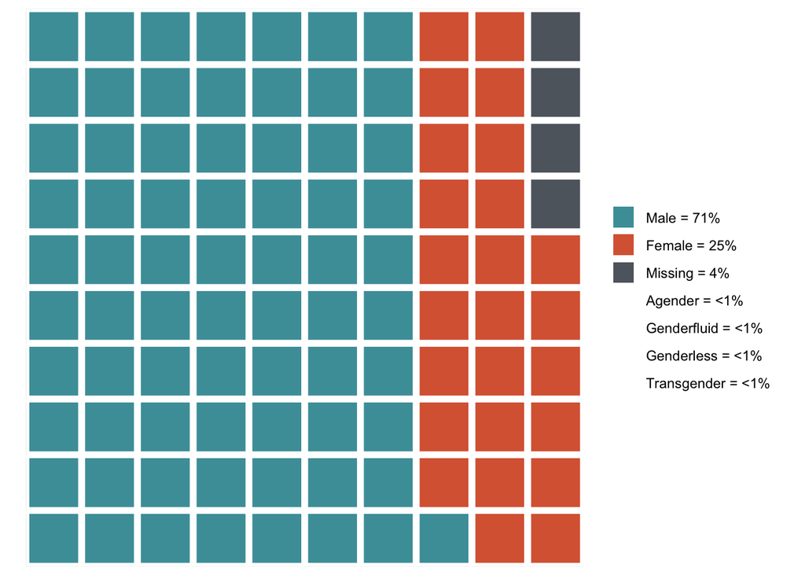

```r
# Waffle v3. Better but still not super happy with it. Would need to use a lot of waffle squares in order for all categories to be represented visually. I think this could work but would need further notes for the reader. I also was interested in seeing if I could a get a glyph to work (specifically the mask one) but did not have luck.

#library(extrafont)
#font_import()
#loadfonts()
#fonts()[grep("Awesome", fonts())]

genderpropwaffle3 <- c(`Male = 71%` = 71,
                       `Female = 25%` = 25,
                       `Missing = 4%` = 4,
                       `Agender = <1%` = 0,
                       `Genderfluid = <1%` = 0,
                       `Genderless = <1%` = 0,
                       `Transgender = <1%` = 0)

waffle(genderpropwaffle3,
       colors = c("#4B9EA8",
                  "#DA6541",
                  "#5F666E",
                  "#FFFFFF",
                  "#FFFFFF",
                  "#FFFFFF",
                  "#FFFFFF"))
```